# Primerjava ploščin pod ROC krivuljo

# Uvod

V seminarski nalogi želimo prikazati uporabo ROC krivulj in kako nam pomagajo pri odločanju med dvema klasifikatorjema. V ta namen bomo z uporabo permutacijskih testov na različnih podatkih primerjali AUC vrednosti markerjev. Preverili bomo lastnosti različnih permutacijskih testov za različno generirane podatke (10 scenarijev) in jih med seboj primerjali.

# Teoretične osnove

## ROC krivulje in AUC

Za začetek si poglejmo, kaj so ROC krivulje in kaj je mera AUC. ROC krivulja (ang. curve - receiver operating characteristic curve) je grafični prikaz, ki prikazuje uspešnost klasifikacijskega modela pri vseh pragovih klasifikacije. Prikazuje dva parametra:

- Stopnja resnično pozitivnih (TPR - True positive rate)
- Stopnja lažno pozitivnih (FPR - False positive rate)

Definirajmo še kratice:

- TP (true positive): št. resnično pozitivnih primerov
- TN (true negative): št. resnično negativnih primerov
- FP (false positive): št. lažno pozitivnih primerov
- FN (false negative): št. lažno negativnih primerov

Stopnja resnično pozitivnih (TPR) je tako definirana kot:

$$TPR = \frac{TP}{TP+FN}$$
Stopnja lažno pozitivnih (FPR) pa kot:

$$FPR = \frac{FP}{FP+TN}$$
ROC krivulja nariše TPR v primerjavi s FPR pri različnih pragovih klasifikacije. Z nižanjem praga za razvrstitev je več postavk opredeljenih kot pozitivnih, kar povečuje tako lažno kot resnično pozitivne.

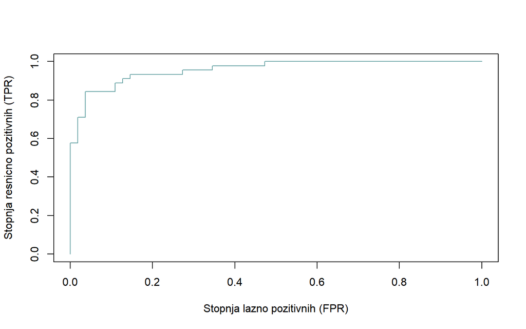

Primer ROC krivulje

AUC (Area Under the ROC Curve) predstavlja ploščino pod ROC krivuljo in s tem predstavlja skupno merilo uspešnosti za vse možne pragove klasifikacije. ROC torej predstavlja verjetnostno krivuljo, AUC pa predstavlja stopnjo ali merilo ločljivosti. Pove nam, kako dobro model razlikuje med posameznimi razredi. Višji kot je AUC, boljši je model pri napovedovanju oziroma določanju razredov.

Primer takšnega klasifikacijskega problema je na primer določanje bolnih in zdravih oseb na podlagi nekega markerja. V tem primeru visok AUC pomeni boljše razlikovanje med bolnimi in zdravimi, kar je običajno tudi naš cilj.

Kot smo omenili že v uvodu, se bomo v sklopu naloge odločali med dvema različnima markerjema. Tudi v tem primeru si želimo marker, ki ima višjo vrednost AUC. Recimo, da želimo da podlagi krvne preiskave določiti, ali mora neka oseba na nadaljne preiskave ali ne. Lahko bi namesto AUC za merilo kakovosti markerja vzeli samo stopnjo resnično pozitivnih primerov in jo maksimizirali. S pomočjo takega kriterija, bi najverjetneje zajeli večji delež bolnih, vendar pa se nam v tem primeru lahko zgodi, da bo na dodatnih preiskavah tudi veliko zdravih ljudi. Tako je najboljša mera v takem primeru AUC, saj s tem preverjamo, kako dobro nek marker loči med bolnimi in zdravimi.

## Permutacijski test

Za testiranje hipotez bomo uporabljali permutacijski test. Permutacijski test je zelo splošen pristop za testiranje statističnih hipotez, saj nima predpostavk o porazdelitvah in je zato tudi zelo primeren, kadar podatki niso skladni s predpostavko o njihovi porazdelitvi.

Porazdelitev testne statistike je generirana iz podatkov samih ob ničelni hipotezi, ki predpostavlja, da so vsi možni pari dveh spremenljivk enako verjetni. To dosežemo tako, da podatke ene spremenljivke naključno porazdelimo, drugo spremenljivko pa fiksiramo. Na koncu primerjamo dobljeno vrednost testne statistike in iz generirane porazdelitve odčitamo p-vrednost.

# Praktičen primer

Raziskovalec v medicini bi rad s pomočjo vrednosti v krvi (markerji) napovedoval ali ima posameznik neko bolezen. Zbral je podatke o dveh različnih markerjih, med katerima se želi odločiti - izbral bi rad tistega, ki bo bolje napovedoval prisotnost bolezni.

## Generiranje in pregled podatkov

Radi bi zgenerirali neke dejanske podatke za naš primer. Potrebujemo torej dva markerja, ki sta medsebojno odvisna in imata različen vpliv na to, ali ima posameznik bolezen ali ne.

Določimo, da markerja prihajata iz multivariatne normalne porazdelitve

$$X\sim N(\mu,\Sigma),$$
kjer je $\mu$ vektor povprečij in $\Sigma$ variančno-kovariančna matrika.

Za nadalnje prikaze in testiranje bomo privzeli:

- $\mu_1 = \mu_2 = 0$
- $\sigma_1 = \sigma_2 = 1$
- $\rho = 0.4$

kjer smo z $\rho$ označili korelacijo med markerjema. Velja torej:

- $X_1 \sim N(0,1)$
- $X_2 \sim N(0,1)$

Ko določimo porazdelitvi markerjev, določimo še, kako vplivata na to, ali ima posameznik bolezen ali ne. To shranimo v spremenljivko $Y$, ki jo generiramo kot linearno kombinacijo markerjev, kjer s pomočjo koeficientov določimo, kako močno je posamezen marker povezan z prisotnostjo bolezni. V našem primeru bomo $Y$ generirali kot:

$$Y=6X_1+2X_2+\epsilon,$$
kjer je $\epsilon$ napaka, ki je porazdeljena standardno normalno. Vrednosti pretvorimo v $0$ in $1$ tako, da si pogledamo večji vzorec ($10000$ enot) in na podlagi tega določimo mejno vrednost $Y$ tako, da bo približno polovica posameznikov imela bolezen in polovica ne. To naredimo tako, da na velikem vzorcu izračunamo mediano spremenljivke $Y$ in vse vrednosti, ki so manjše od mediane, postavimo na $0$ (nima bolezni) ter vse, ki so večje od mediane, postavimo na $1$ (ima bolezen).

V spodnji tabeli je primer prvih nekaj vrstic tako generiranega vzorca, kjer je velikost vzorca enaka $100$.

Izsek iz tabele podatkov

| y | X1 | X2 |
| --- | --- | --- |
| 0 | -1.3415135 | -0.0601132 |
| 0 | -0.4214683 | -1.9831269 |
| 0 | -0.4725821 | 0.4383272 |
| 0 | -0.4872516 | -0.9052361 |
| 1 | 0.7217734 | -0.7579783 |
| 1 | 0.8180290 | -1.3138188 |

Poglejmo si, kakšni sta dobljeni ROC krivulji in kakšni sta pripadajoči AUC vrednosti.

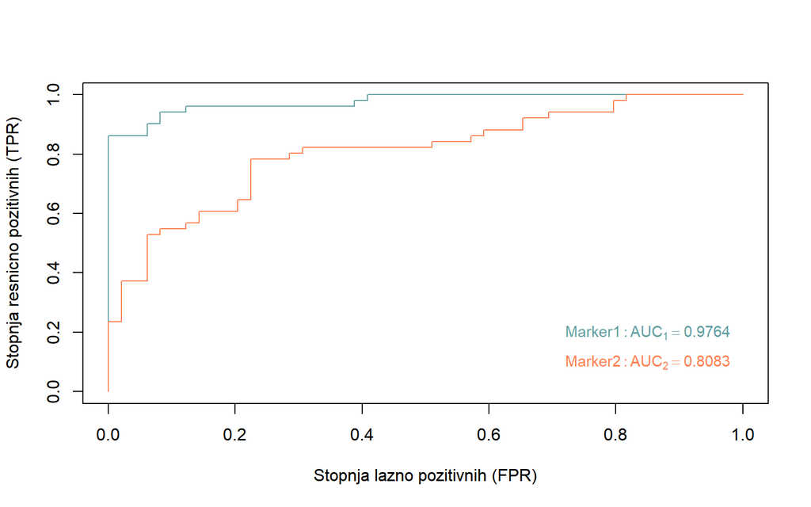

ROC krivulji na generiranem vzorcu

Iz ROC krivulje lahko vidimo, da je na naših podatkih Marker 1 boljši kot Marker 2. Vrednosti AUC, torej velikosti ploščin pod ROC krivuljama pa sta:

- $AUC_1: 0.976$
- $AUC_2: 0.808$

## Postavitev hipoteze in testiranje

Želimo statistično preveriti, ali je eden izmed markerjev boljši kot drugi. Za testiranje bomo uporabili že prej opisani permutacijski test, ki pa ga bomo naredili na 4 različne načine. Načini se ločijo glede na to, katere stolpce bomo permutirali (prisotnost bolezni/vrednosti markerjev) in glede na to, katero mero bomo uporabili za testno statistiko (razlika AUC ali razmerje AUC). Teste označimo z zaporednimi števili. Parametri oziroma definicije testov so prikazani v spodnji tabeli.

Definicije testov

|  | Permutiranje | Mera |
| --- | --- | --- |
| Test 1 | X1,X2 | Razlika |
| Test 2 | y | Razlika |
| Test 3 | X1,X2 | Razmerje |
| Test 4 | y | Razmerje |

Izkaže se, da v kolikor želimo, da naši testi delujejo tudi za različno porazdeljene markerje, moramo pred izračunom testne statistike in permutiranjem markerja pretvoriti tako, da jim priredimo range. S tem na nek način standardiziramo spremenljivki, brez da bi s tem vplivali na vrednosti AUC statistike.

V primeru, ko permutiramo stolpec z boleznimi, se moramo zavedati, da s tem uničimo vpliv markerjev na izid bolezni, torej bi v takšnem primeru markerja morala biti enakovredna, vendar pa bi imela oba vrednost AUC enako $\frac{1}{2}$.

V nasprotju s permutacijo po stolpcu z boleznimi, v primeru permutiranja po markerjih želimo obdržati njuno medsebojno odvisnot in vpliv na izid bolezni. To naredimo tako, da v vsaki vrstici markerja slučajno zamenjamo ali ne.

### Ničelna domneva

Naša ničelna domneva je, da sta markerja enakovredna, oziroma, da sta njuni vrednosti AUC enaki. Pri permutacijskih testih, kjer imamo za testno statistiko razliko AUC obeh markerjev (Test 1 in Test 2) je

$$H_0: AUC_1-AUC_2=0 \text{ (razlika je enaka 0)}.$$

Vrednost testne statistike na vzorcu je enaka $AUC_1-AUC_2= 0.168$.

Pri permutacijskih testih, kjer imamo za testno statistiko razmerje AUC obeh markerjev (Test 3 in Test 4), pa je

$$H_0: \frac{AUC_1}{AUC_2}=1 \text{ (razmerje je enako 1)}.$$
Vrednost testne statistike na vzorcu je enaka $\frac{AUC_1}{AUC_2}= 1.208$.

Vidimo, da so vsi testi dvostranski. Pri testiranju bomo povsod uporabljali stopnjo značilnosti $\alpha = 0.05$.

### Rezultati testov

Poglejmo si, kakšne rezultate dobimo na generiranih podatkih. Rezultate bomo za vsak test prikazali tudi grafično, da vidimo še dobljene porazdelitve testnih statistik pod ničelno domnevo. Na porazdelitvi bo s sivo barvo prikazano tudi kritično območje.

**Rezultati za Test 1 (permutiranje X1,X2 in razlika)**

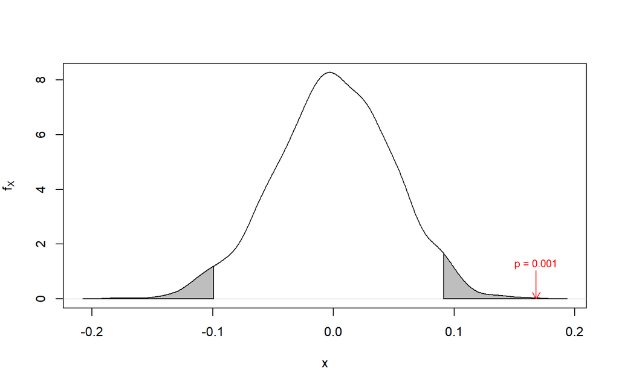

Porazdelitev testne statistike pod H_0 in rezultat testa za Test 1

Dobljena vrednost testne statistike je enaka 0.168, izračunana p-vrednost znaša 0.001. Tudi iz slike lahko razberemo, da je testna statistika znotraj kritičnega območja, zato v tem primeru pri stopnji značilnosti $\alpha=0.05$ zavrnemo $H_0$ in rečemo, da obstaja statistično značilna razlika med AUC markerjev.

**Rezultati za Test 2 (permutiranje y in razlika)**

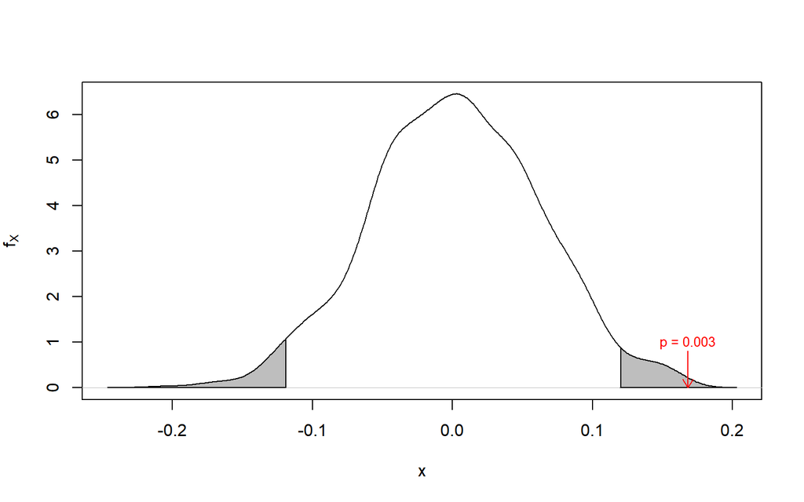

Porazdelitev testne statistike pod H_0 in rezultat testa za Test 2

Dobljena vrednost testne statistike je enaka kot v prejšnjem testu, torej 0.168, izračunana p-vrednost pa znaša 0.003. Ponovno razberemo tako iz izračunanih vrednosti kot iz grafičnega prikaza, da je testna statistika znotraj kritičnega območja, zato pri stopnji značilnosti $\alpha=0.05$ zavrnemo $H_0$ in rečemo, da obstaja statistično značilna razlika med AUC markerjev.

**Rezultati za Test 3 (permutiranje X1,X2 in razmerje)**

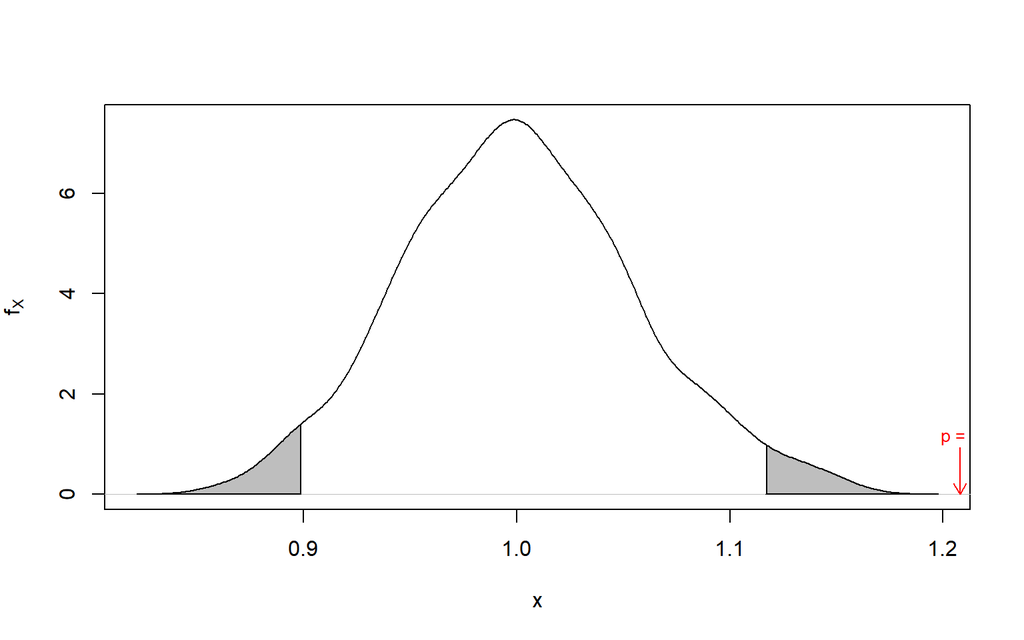

Porazdelitev testne statistike pod H_0 in rezultat testa za Test 3

Dobljena vrednost testne statistike znaša 1.208, izračunana p-vrednost pa 0. Kot vidimo, pri stopnji značilnosti $\alpha=0.05$ ponovno zavrnemo ničelno domnevo in trdimo, da obstaja statistično značilna razlika med AUC vrednostima markerjev.

**Rezultati za Test 4 (permutiranje y in razmerje)**

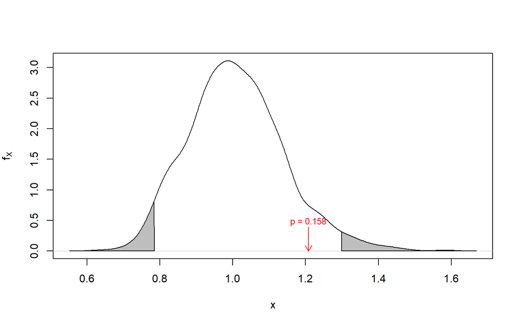

Porazdelitev testne statistike pod H_0 in rezultat testa za Test 4

Dobljena vrednost testne statistike znaša 1.208, izračunana p-vrednost pa 0.158. Tokrat pri stopnji statistične značilnosti $\alpha=0.05$ ne moremo zavrnit ničelne domneve.

## Lastnosti testov

Preverili bomo lastnosi vseh štirih testov in izbrali tistega, ki je najbolj primeren za naše podatke.

Za preverjanje velikosti testa bomo podatke simulirali pod ničelno hipotezo, ki pravi, da je vrednost AUC enaka za oba parametra. Torej izenačimo $\beta_1$ in $\beta_2$ in izid generiramo kot $Y=3X_1+3X_2+\epsilon$. Za določitev velikosti testa večkrat simuliramo podatke in izvedemo test, potem pa pogledamo delež zavrnjenih ničelnih hipotez, za katerega želimo, da je manjši ali enak stopnji značilnosti $\alpha=0.05$.

Za preverjanje moči testa bomo podatke simulirali s pravimi vrednostmi, ki smo jih določili na začetku poglavja. Pogledali bomo, kakšno moč ima posamezen test, tako da bomo podatke simulirali večkrat in na koncu izračunali delež zavrnjenih ničelnih hipotez. Za ta delež si seveda želimo, da je čimvečji.

Odločimo se za $10000$ simulacij za vsak test za velikosti in moč.

Lastnosti testov

|  | Velikost | Moc |
| --- | --- | --- |
| Test 1 | 0.05 | 0.98 |
| Test 2 | 0.01 | 0.91 |
| Test 3 | 0.05 | 0.98 |
| Test 4 | 0.01 | 0.90 |

# Lastnosti permutacijskih testov na različnih scenarijih

Pogledali smo že, kako naši permutacijski testi delujejo na primeru, kjer sta markerja sicer korelirana, vendar sta enako in normalno porazdeljena. Želimo preveriti, kako se permutacijski testi obnašajo še v drugih, bolj ali manj ekstremnih primerih. V ta namen definiramo različne scenarije, glede na porazdelitve markerjev in glede na velikost vplivov markerjev na izid bolezni.

Podatke generiramo na enak način kot v prejšnjem primeru, le da spreminjamo porazdelitve, velikosti vplivov in velikost začetnega vzorca. V vseh primerih smo za lastnosti testa uporabili $10000$ simulacij. Glede na število izvedenih simulacij, lahko izračunamo 95% interval zaupanja za velikost testa, v kolikor je velikost enaka 0.05. Dobljen interval zaupanje je [0.046, 0.054] in če dobimo velikost testa izven tega intervala, posumimo, da velikost testa ni prava (0.05).

Hitro lahko ugotovimo, da je časovna zahtevnost simulacij za več različnih scenarijev zelo velika. V veliko pomoč v programu R nam je tako lahko paket `parallel` in funkcija `parSapply`, s pomočjo katerih simulacije prenesemo na več jeder znotraj enega procesorja in s tem zmanjšamo časovno zahtevnost. Na tak način smo zmanjšali več dnevne simulacije na simulacijo, dolgo približno 3 ure. Seveda je v tem primeru dolžina simulacije odvisna od zmogljivosti računalnika, predvsem od tega, koliko jedrni procesor se nahaja v računalniku.

## Rezultati simulacij

### Prvotni scenarij (enaka porazdelitev)

Prvotni primer smo si pogledali že v prejšnjem razdelku. Kot referenco in za lažjo primerjavo med različnimi scenariji pa še enkrat poglejmo same lastnosti testov.

**Predpostavke**:

$n = 100$

$X_1 \sim N(0,1)$

$X_2 \sim N(0,1)$

$\rho = 0.4$

$\beta_1 = 6$

$\beta_2 = 2$

**Testni statistiki na enem vzorcu**:

$AUC_1-AUC_2 = 0.168$

$AUC_1/AUC_2 = 1.208$

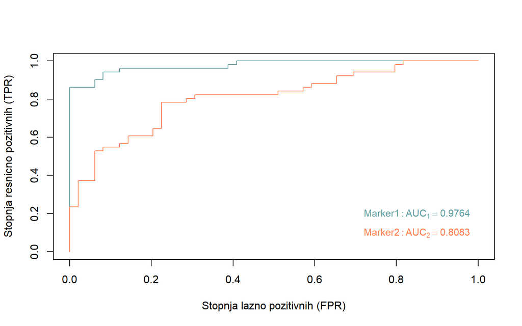

ROC krivulji za Scenarij 1

Lastnosti testov za Scenarij 1

|  | Velikost | Moc |
| --- | --- | --- |
| Test 1 | 0.05 | 0.98 |
| Test 2 | 0.01 | 0.91 |
| Test 3 | 0.05 | 0.98 |
| Test 4 | 0.01 | 0.90 |

**Komentar:** V primeru, ko imamo enako in normalno porazdeljena markerja, so vse moči testov zadovoljivo visoke. Prav tako so velikosti testov ustrezne, saj so manjše ali enake 0.05. V primeru, ko mešamo po stolpcu z boleznimi, so velikosti testov zelo majhne in velikosti velike, kar je najverjetneje zaradi ugodnih predpostavk. Kot smo že omenili, tako permutiranje uniči povezanost markerjev s pojavom bolezni.

### Različni pričakovani vrednosti markerjev

Zanima nas, kaj se zgodi, če glede na prvotni primer enakih normalnih porazdelitev pri enem od markerjev porazdelitev malo zamaknemo. S tem namenom smo spremenili povprečno vrednost drugega markerja iz $0$ na $2$.

**Predpostavke**:

$n = 100$

$X_1 \sim N(0,1)$

$X_2 \sim N(2,1)$

$\rho = 0.4$

$\beta_1 = 6$

$\beta_2 = 2$

**Testni statistiki na enem vzorcu**:

$AUC_1-AUC_2 = 0.104$

$AUC_1/AUC_2 = 1.12$

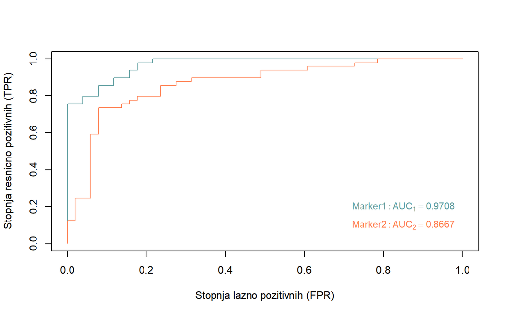

ROC krivulji za Scenarij 2

Lastnosti testov za Scenarij 2

|  | Velikost | Moc |
| --- | --- | --- |
| Test 1 | 0.05 | 0.99 |
| Test 2 | 0.01 | 0.91 |
| Test 3 | 0.05 | 0.98 |
| Test 4 | 0.01 | 0.91 |

**Komentar:** Opazujemo zamaknjeno porazdelitev oziroma različni pričakovani vrednosti markerjev. Kjub temu, da je zaradi kombinacije predpostavk v tem primeru AUC vrednost drugega markerja lahko bolj primerljiva z AUC vrednostjo prvega markerja, se lastnosti testov ne spremenijo kaj dosti. Izkazalo se je, da v kolikor v testih ne bi uporabili rangiranja in s tem na nek način standardiziranja spremenljivk, bi bile tako velikosti kot tudi moči testov veliko slabše (v primeru zamaknjene porazdelitve).

### Neodvisna markerja

Če želimo preveriti vpliv odvisnosti markerjev, moramo preveriti, kakšne rezultate dobimo pri različnih korelacijskih faktorjih med markerjema. V tem primeru bomo pogledali rezultate za nekorelirana markerja.

**Predpostavke**:

$n = 100$

$X_1 \sim N(0,1)$

$X_2 \sim N(0,1)$

$\rho = 0$

$\beta_1 = 6$

$\beta_2 = 2$

**Testni statistiki na enem vzorcu**:

$AUC_1-AUC_2 = 0.264$

$AUC_1/AUC_2 = 1.378$

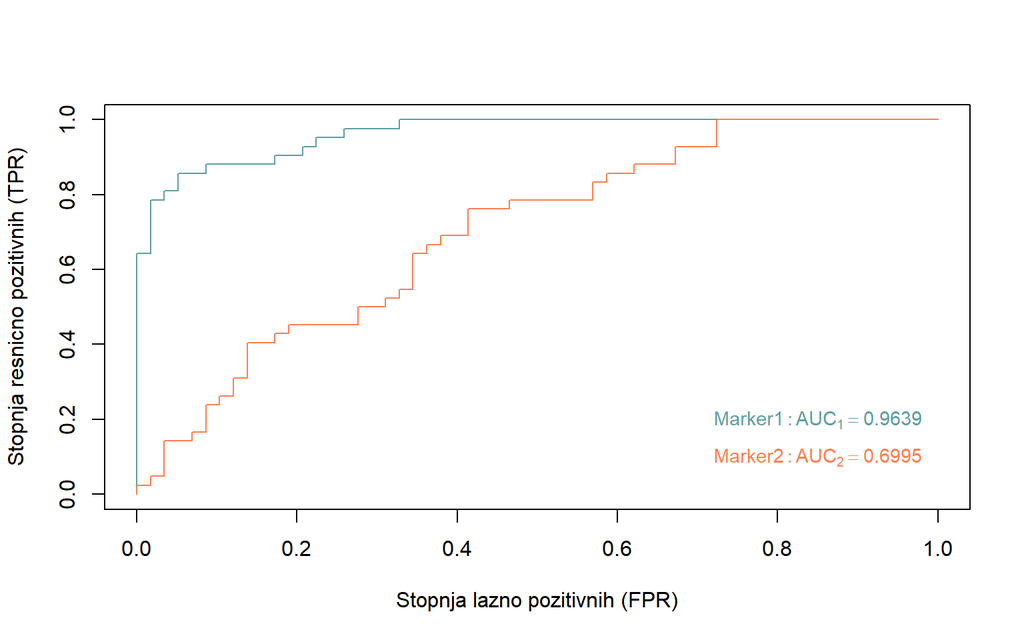

ROC krivulji za Scenarij 3

Lastnosti testov za Scenarij 3

|  | Velikost | Moc |
| --- | --- | --- |
| Test 1 | 0.05 | 1 |
| Test 2 | 0.02 | 1 |
| Test 3 | 0.05 | 1 |
| Test 4 | 0.02 | 1 |

**Komentar:** Glede na razliko v ROC krivuljah sklepamo, da je lažje ločiti, kateri marker bolje napoveduje oziroma ima večji vpliv na izid bolezni. Vrednost AUC drugega markerja je v primeru nekoreliranosti s prvim nižja in zato tudi hitreje zavrnemo ničelno domnevo. Z našimi simulacijami smo $H_0$ zavrnili skoraj vedno (vrednosti so zaokrožene).

### Velika koreliranost

Če želimo preveriti, kako odvisnost markerjev vpliva na teste, moramo preveriti, kakšne rezultate dobimo pri različnih korelacijskih faktorjih med markerjema. V tem primeru bomo pogledali rezultate za močno korelirana markerja.

**Predpostavke**:

$n = 100$

$X_1 \sim N(0,1)$

$X_2 \sim N(0,1)$

$\rho = 0.9$

$\beta_1 = 6$

$\beta_2 = 2$

**Testni statistiki na enem vzorcu**:

$AUC_1-AUC_2 = 0.005$

$AUC_1/AUC_2 = 1.005$

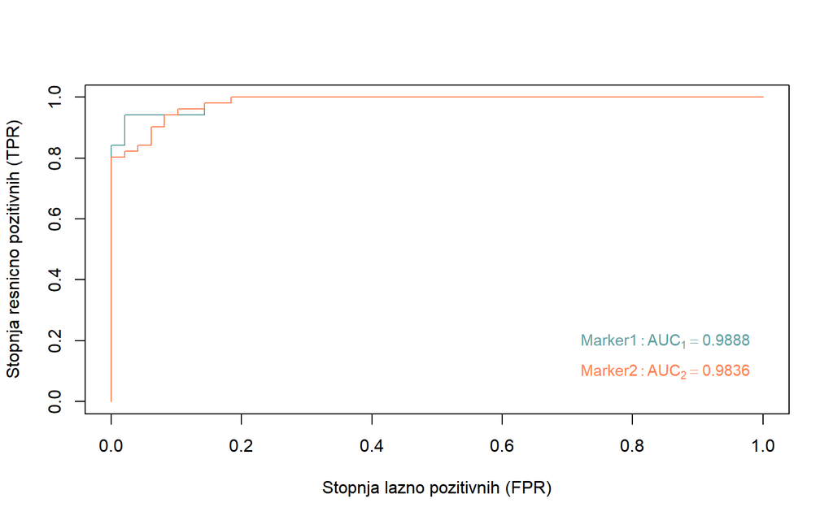

ROC krivulji za Scenarij 4

Lastnosti testov za Scenarij 4

|  | Velikost | Moc |
| --- | --- | --- |
| Test 1 | 0.05 | 0.52 |
| Test 2 | 0.00 | 0.07 |
| Test 3 | 0.04 | 0.52 |
| Test 4 | 0.00 | 0.07 |

**Komentar:** V nasprotju z nekoreliranimi podatki pri močno koreliranih praktično ne moremo več ločiti, kateri marker je tisti, ki zares vpliva na izid bolezni. V takem primeru smo dobili vrednosti AUC zelo visoke za oba markerja in moč testa je posledično veliko nižja. Velikost testa je malo manjša kot v ostalih primerih z normalno porazdeljenimi markerji.

### Podoben vpliv

Preverimo, kaj se zgodi, ko sta si $\beta_1$ in $\beta_2$ bolj podobni in imata s tem markerja podoben, vendar še vedno različen vpliv.

**Predpostavke**:

$n = 100$

$X_1 \sim N(0,1)$

$X_2 \sim N(0,1)$

$\rho = 0.4$

$\beta_1 = 6$

$\beta_2 = 5$

**Testni statistiki na enem vzorcu**:

$AUC_1-AUC_2 = -0.024$

$AUC_1/AUC_2 = 0.975$

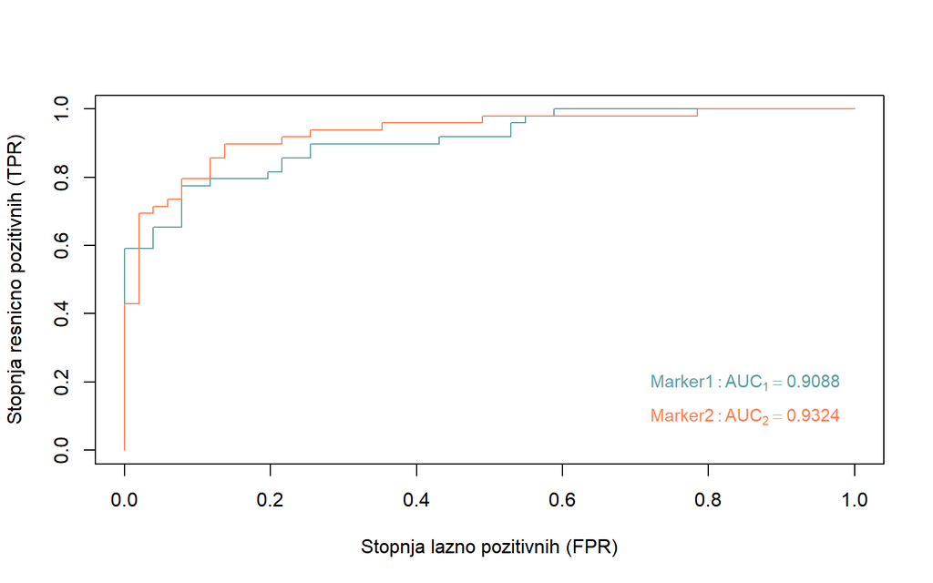

ROC krivulji za Scenarij 5

Lastnosti testov za Scenarij 5

|  | Velikost | Moc |
| --- | --- | --- |
| Test 1 | 0.04 | 0.11 |
| Test 2 | 0.01 | 0.03 |
| Test 3 | 0.05 | 0.11 |
| Test 4 | 0.01 | 0.03 |

**Komentar:** Ko imata markerja podoben oziroma skoraj enak vpliv na izid bolezni, sta tudi AUC vrednosti zelo podobni. Posledično je seveda moč testa manjša, opazimo pa tudi, da se je v primeru Testa 1 (mešanje po markerjih in razlika) znižala velikost za 1.o.t. Moč testa bi morda lahko povečali, če bi imeli večji vzorec, vseeno pa bi le ta ostala zelo majhna.

### Podobni beti, neodvisna markerja

Glede na to, da smo pri podobnih vrednostih $\beta_1$ in $\beta_2$ dobili majhne moči testov, pri neodvisnih markerjih pa zelo velike moči testov, poglejmo, kaj se zgodi, če uporabimo obe lastnosti podatkov hkrati.

**Predpostavke**:

$n = 100$

$X_1 \sim N(0,1)$

$X_2 \sim N(0,1)$

$\rho = 0$

$\beta_1 = 6$

$\beta_2 = 5$

**Testni statistiki na enem vzorcu**:

$AUC_1-AUC_2 = 0.107$

$AUC_1/AUC_2 = 1.14$

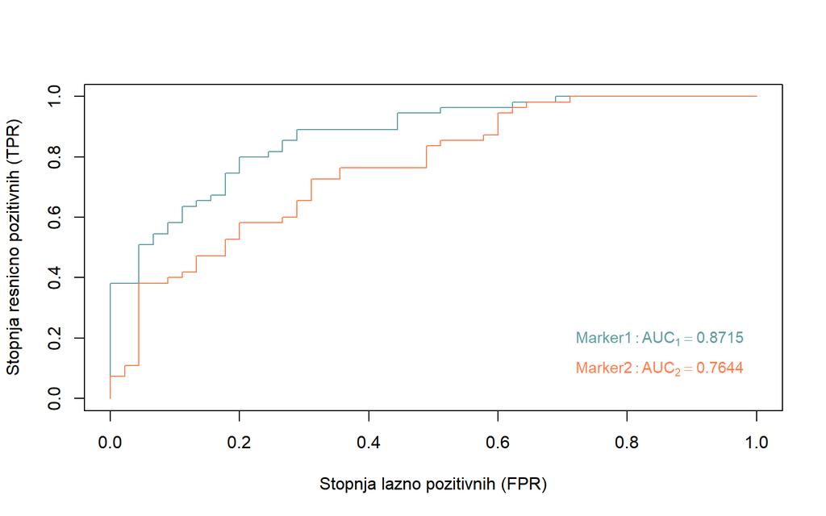

ROC krivulji za Scenarij 6

Lastnosti testov za Scenarij 6

|  | Velikost | Moc |
| --- | --- | --- |
| Test 1 | 0.05 | 0.16 |
| Test 2 | 0.02 | 0.08 |
| Test 3 | 0.05 | 0.15 |
| Test 4 | 0.02 | 0.08 |

**Komentar:** Vrednosti AUC sta si v tem primeru nekoliko bolj različni kot pri prejšnjih primerih, vendar vseeno zelo podobni. Moč testa je zato majhna, kar pa smo lahko pričakovali.

### Majhen vzorec

Želimo preveriti, kako se permutacijski testi obnesejo v primeru zelo majhnega vzorca. Generiramo manjši začetni vzorec, ostale predpostavke pa pustimo takšne, kot so bile v prvotnem primeru.

**Predpostavke**:

$n = 20$

$X_1 \sim N(0,1)$

$X_2 \sim N(0,1)$

$\rho = 0.4$

$\beta_1 = 6$

$\beta_2 = 2$

**Testni statistiki na enem vzorcu**:

$AUC_1-AUC_2 = 0.209$

$AUC_1/AUC_2 = 1.271$

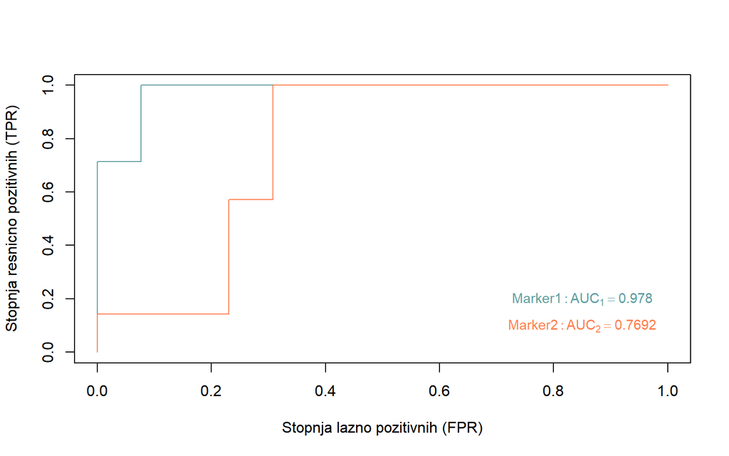

ROC krivulji za Scenarij 7

Lastnosti testov za Scenarij 7

|  | Velikost | Moc |
| --- | --- | --- |
| Test 1 | 0.03 | 0.29 |
| Test 2 | 0.01 | 0.13 |
| Test 3 | 0.03 | 0.29 |
| Test 4 | 0.00 | 0.13 |

**Komentar:** Kadar imamo tako majhen vzorec, testi niso več tako zanesljivi. Težaven je že izračun ROC krivulje in posledično vrednosti AUC.

### Gamma porazdelitev

Poglejmo še primer, ko markerja nista generirana iz normalne porazdelitve. V tem primeru naj bosta oba generirana iz $\Gamma(2,2)$ ter medsebojno korelirana z $\rho=0.5$.

**Predpostavke**:

$n = 100$

$X_1 \sim \Gamma(2,2)$

$X_2 \sim \Gamma(2,2)$

$\rho = 0.5$

$\beta_1 = 6$

$\beta_2 = 2$

**Testni statistiki na enem vzorcu**:

$AUC_1-AUC_2 = 0.2$

$AUC_1/AUC_2 = 1.254$

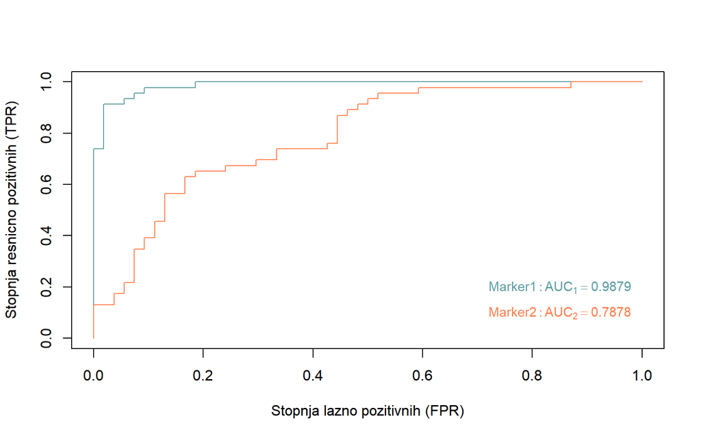

ROC krivulji za Scenarij 8

Lastnosti testov za Scenarij 8

|  | Velikost | Moc |
| --- | --- | --- |
| Test 1 | 0.05 | 0.93 |
| Test 2 | 0.01 | 0.78 |
| Test 3 | 0.05 | 0.93 |
| Test 4 | 0.01 | 0.79 |

**Komentar:** V primeru drugačne porazdelitve (ne normalne), so testi še vedno zelo zanesljivi. Nekoliko manjšo moč imata Test 2 in Test 4, torej testa, kjer permutiramo po stolpcu z boleznimi. Kot smo že omenili, tak test ni pravilen, saj ne uniči le razlike med markerjema, pač pa celoten vpliv markerjev.

### Poissonova porazdelitev

Poglejmo si še primer, ko markerja generiramo iz diskretne porazdelitve. Naj bo $X_1 \sim Pois(2)$, $X_2 \sim Pois(2)$ in $\rho=0.5$.

**Predpostavke**:

$n = 100$

$X_1 \sim Pois(2)$

$X_2 \sim Pois(2)$

$\rho = 0.5$

$\beta_1 = 6$

$\beta_2 = 2$

**Testni statistiki na enem vzorcu**:

$AUC_1-AUC_2 = 0.144$

$AUC_1/AUC_2 = 1.175$

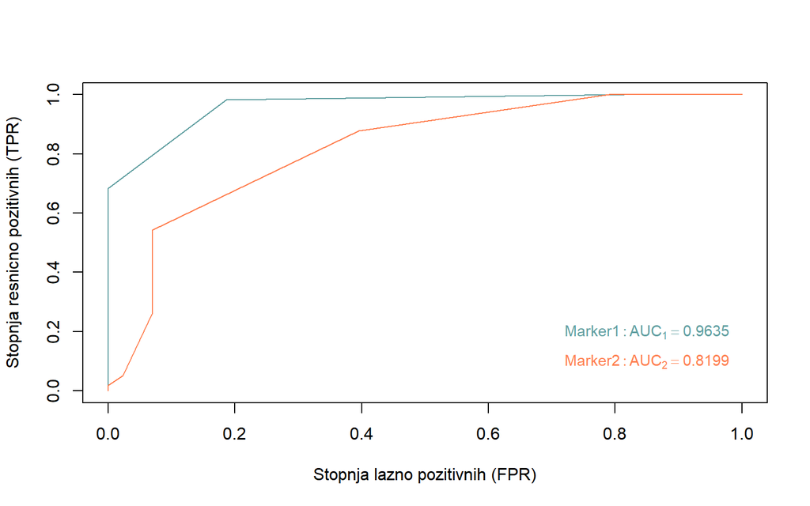

ROC krivulji za Scenarij 9

Lastnosti testov za Scenarij 9

|  | Velikost | Moc |
| --- | --- | --- |
| Test 1 | 0.04 | 0.90 |
| Test 2 | 0.01 | 0.70 |
| Test 3 | 0.04 | 0.90 |
| Test 4 | 0.01 | 0.69 |

**Komentar:** Tudi v primeru diskretne porazdelitve se Test 1 in Test 3 izkažeta za zanesljiva. Moč testa je visoka, primerni pa sta tudi velikosti testov.

### Različni porazdelitvi

Pogledali smo že veliko različnih scenarijev, sedaj pa poglejmo še, kaj se zgodi, če sta markerja iz različnih porazdelitev. Naj bo $X_1 \sim N(0,1)$, $X_2 \sim Exp(1)$ in markerja neodvisna.

**Predpostavke**:

$n = 100$

$X_1 \sim N(0,1)$

$X_2 \sim Exp(1)$

$\rho = 0$

$\beta_1 = 6$

$\beta_2 = 2$

**Testni statistiki na enem vzorcu**:

$AUC_1-AUC_2 = 0.355$

$AUC_1/AUC_2 = 1.561$

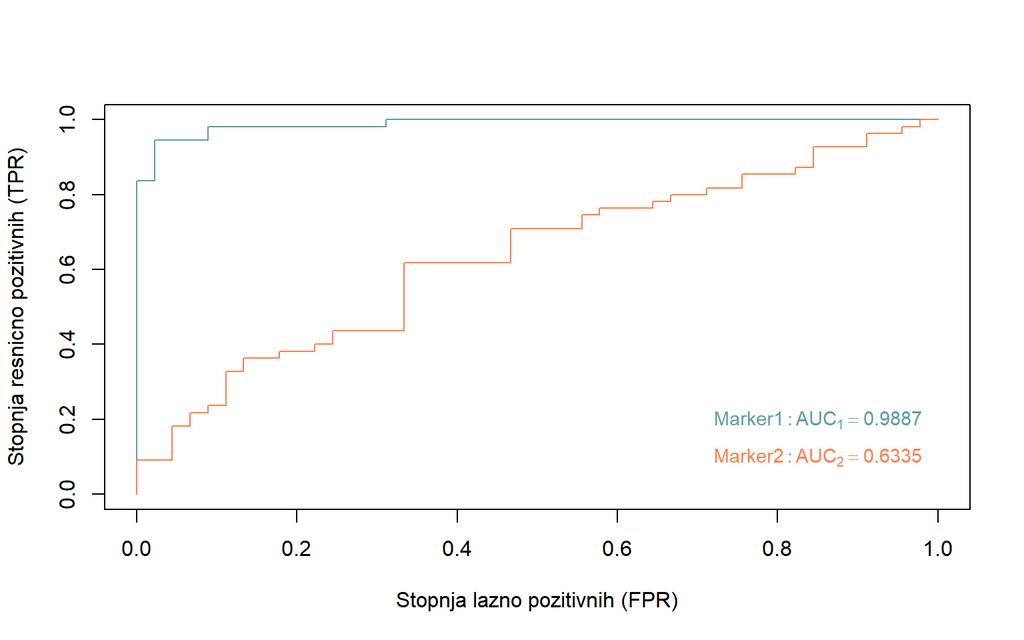

ROC krivulji za Scenarij 10

Lastnosti testov za Scenarij 10

|  | Velikost | Moc |
| --- | --- | --- |
| Test 1 | 0.16 | 1 |
| Test 2 | 0.10 | 1 |
| Test 3 | 0.16 | 1 |
| Test 4 | 0.09 | 1 |

## Primerjava lastnosti testov glede na scenarij

Ker smo tekom simulacij in pregledovanja lastnosti testov že razbrali, da v primeru permutiranja po stolpcu z boleznimi test ne deluje dobro, bomo v tem razdelku podrobneje pogledali le teste, kjer permutiramo po markerjih.

Testa se torej razlikujeta le po tem, ali za testno statistiko vzamemo razliko ali razmerje AUC vrednosti markerjev. V spodnji tabeli so prikazane velikosti in moči za različna testa in scenarije.

Velikosti in moči za Test 1 in Test 3

|  | Velikost Razlika | Velikost Razmerje | Moč Razlika | Moč Razmerje |
| --- | --- | --- | --- | --- |
| Prvotni podatki | 0.05 | 0.05 | 0.98 | 0.98 |
| Različni pričakovani vrednosti | 0.05 | 0.05 | 0.99 | 0.98 |
| Neodvisna markerja | 0.05 | 0.05 | 1.00 | 1.00 |
| Velika koreliranost | 0.05 | 0.04 | 0.52 | 0.52 |
| Podoben vpliv | 0.04 | 0.05 | 0.11 | 0.11 |
| Podoben vpliv in neodvisna | 0.05 | 0.05 | 0.16 | 0.15 |
| Majhen vzorec | 0.03 | 0.03 | 0.29 | 0.29 |
| Gamma porazdelitev | 0.05 | 0.05 | 0.93 | 0.93 |
| Poissonova porazdelitev | 0.04 | 0.04 | 0.90 | 0.90 |
| Različni porazdelitvi | 0.16 | 0.16 | 1.00 | 1.00 |

# Pot do uspeha

Pri definiranju podatkov in permutacijskih testov smo pred končnimi verzijami naleteli na kar nekaj težav, ki so vredne omembe.

Najprej smo poskusili s permutiranjem celotnih stolpcev markerjev, torej da v vsakem stolpcu naključno premešamo vse vrednosti. Pri tem smo vedno dobili velikosti prvega in tretjega testa (ko premutiramo po markerjih) enake nič. Ugotovili smo, da tako mešanje ni primerno, ker s tem uničimo odvisnost med markerjema in izidom.

Da bi se izognili izničevanju vpliva markerjev, smo tako poskusili z mešanjem vrednosti znotraj skupin bolnih in zdravih, vendar v tem primeru prav tako delno uničimo odvisnost med markerji in izidom. Posledično smo se nato odločili, da je najboljši način za ohranjanje vplivov permutiranje znotraj posameznikov. Za vsakega posameznika torej naključno zamenjamo vrednosti prvega in drugega markerja. Tako permutiranje se je izkazalo za uspešno, saj na ta način dobimo prave velikosti testov za prvi in tretji test. Pri permutiranju izida pa nimamo druge možnosti, kot da naključno premešamo celotni stolpec tabele in s tem izničimo odvisnost markerjev in izida.

Najprej smo izvedli permutacijske teste brez uporabe rangov. Ker se je izkazalo, da taki testi niso primerni za markerja, ki nimata povsem enake porazdelitve, smo razmišljali, kako bi porazdelitvi standardizirali. Odločili smo se poskusiti z rangi, s tem pa smo pridobili končne teste, ki so uporabljeni v seminarski nalogi.

Na poti do iskanja pravih testov, ki bodo učitnkoviti in stabilni, pa nam je bila v pomoč tudi funkcija `praise()` iz istoimenskega paketa v programu R. Primer izpisa funkcije je prikazan spodaj.

```r
praise()
```

```
[1] "You are super!"
```

# Zaključek

Pri našem praktičnem primeru smo definirane teste preiskusili na podaktih, ki so bili generirani tako, da je en marker boljši od drugega, med seboj pa sta korelirana. V tem prvotnem primeru sta bila markerja enako (normalno) porazdeljena. Pri prvih treh testih smo ničeno hipotezo, da sta markerja enakovredna, pri stopnji značilnosti 0.05 zavrnili in sklepali, da obstaja statistično značilna razlika med AUC vrednostima markerjev. Ničelne hipoteze pri stopnji značilnosti 0.05 ali manj pa nismo uspeli zavrniti pri četrtem testu.

Pri pregledovanju lastnosti smo si pogledali 10 različnih scenarijev. Zanimalo nas je, kako stabilen je test, če spreminjamo porazdelitve, korelacijo markerjev in velikost vzorca.

Moči testov so bile v primeru majhnega vzorca manjše. V tem primeru smo tudi opazili, da imamo težave z generiranjem ROC krivulj in izračunom AUC.

Testi so imeli zelo majhno moč tudi v primeru skoraj enakega vpliva markerjev. To je bilo pričakovano, saj to pomeni, da noben od markerjev ni izrazito boljši od drugega. Rezultati bi bili podobni, ne glede na to, katerega bi izbrali. Pri podobnem vplivu se je moč rahlo, vendar še vedno zelo malo, dvignila v primeru, ko sta bila markerja neodvisna.

Nekoliko manjše moči testov smo dobili tudi, ko smo imeli močno korelirana markerja. Videli smo, da smo v tem primeru dobili zelo visoki AUC vrednosti obeh markerjev, ki pa sta si bili zelo podobni.

# Viri

- Biček, M., 2009. *Grafični gradnik za merjenje kvalitete klasifikatorja s pomočjo krivulj* (Diplomsko delo). Univerza v Ljubljani, Fakulteta za računalništvo in informatiko, Ljubljana. Dostopno na: http://eprints.fri.uni-lj.si/861/1/Bi%C4%8DekM_UN.pdf
- *Classification: ROC Curve and AUC*. Google Developers. 2020. Dostopno na: https://developers.google.com/machine-learning/crash-course/classification/roc-and-auc
- Jones, M., 2017. *Quick Intro to Parallel Computing in R*. Dostopno na: https://nceas.github.io/oss-lessons/parallel-computing-in-r/parallel-computing-in-r.html
- Narkhede, S., 2018. *Understanding AUC - ROC Curve*. Towards Data Science. Dostopno na: https://towardsdatascience.com/understanding-auc-roc-curve-68b2303cc9c5
- *Receiver operating characteristic*. Wikipedia. 2020. Dostopno na: https://en.wikipedia.org/wiki/Receiver_operating_characteristic